# Ferdous Faculty Applications: 2023

School specific application materials with deadlines.

Md Ferdous Alam https://ferdous-alam.github.io (PhD student, MAE, The Ohio State University)https://mae.osu.edu  
10-23-2022

University

Topic

Deadline

Remarks

Link

Status

Materials

1

Texas Tech (ME)

Compy Sci, ML, AI

Sep 1/open

Donald Docimo

[Link](https://www.depts.ttu.edu/me/department/open_positions.php)

$\sim$

2

SUNNY Binghamton (SSIE)

Autonomous systems

Nov 1/open

-

Link

$\sim$

3

NC State (ISE)

next gen Mfg, robotics

Nov 1/open

-

Link

$\sim$

4

Clemson (ME)

AI/ML, control, robotics

Sep 30/open

-

[Link](https://apply.interfolio.com/102152?source=JobTarget)

$\sim$

5

Iowa State (ME)

ML, computational

Oct 1/open

-

[Link](https://isu.wd1.myworkdayjobs.com/en-US/IowaStateJobs/details/Mechanical-Engineering-Computational-Sciences---Assistant-Associate-Full-Professor_R9077?q=mechanical&)

$\sim$

6

UT Austin (ME)

Mfg, Control, robotics

Nov 1

-

[Link](https://www.me.utexas.edu/people/faculty-jobs)

$\sim$

7

UMich (ME)

Control, Mfg

Nov 1

-

[Link](https://me.engin.umich.edu/about/positions/faculty/)

$\sim$

8

Texas A&M (ME)

Control, robotics, mechatronics

Nov 1

-

[Link](https://apply.interfolio.com/112478)

$\sim$

9

Carnegie Mellon (ME)

Control, robotics, AI/ML

Nov 1

-

[Link](https://www.meche.engineering.cmu.edu/employment.html)

$\sim$

10

Notre Dame (ME)

Robotics, Mfg, Data Sci

Nov 4/Dec 1

-

[Link](https://apply.interfolio.com/112134)

$\sim$

11

Arizona State (ME)

Control, Autonomous, robotics

Nov 5

-

[Link](https://apply.interfolio.com/113817)

$\sim$

12

Northwestern (ME)

Mfg, data analytics, Mfg optiization

Nov 15

-

[Link](https://www.mccormick.northwestern.edu/mechanical/careers/)

$\sim$

13

Boston University (ME)

Mfg, robotics, autonomous, data science, design

Nov 21/Dec 16

-

[Link](https://www.bu.edu/eng/departments/me/open-faculty-positions/#ASSISTANT%20PROFESSOR%20IN%20EMERGING%20AREAS)

$\sim$

14

Oregon State (ME)

Mfg, Control, AI, robotics, mechatronics

Dec 1

-

[Link](https://jobs.oregonstate.edu/postings/125513)

$\sim$

15

Columbia (ME)

Autonomous systems, Desin and Mfg, Robotics

Dec 1

-

[Link](https://apply.interfolio.com/114276)

$\sim$

16

UC Berkeley (ME)

AI design, ML, Mfg

Dec 12

-

[Link](https://aprecruit.berkeley.edu/JPF03635)

$\sim$

17

UT Dallas (ME)

Design, Mfg, Automation, robotics

Oct 31/Dec 31

Justin Koeln

[Link](https://jobs.utdallas.edu/postings/20919)

$\sim$

18

Rice (ME)

Design, Control, robotics

Dec 31

-

[Link](https://apply.interfolio.com/114276)

$\sim$

19

UW Madison (ME)

Autonomous systems, Mfg, Learning

Jan 12

-

[Link](https://apply.interfolio.com/114276)

$\sim$

### Ferdous past research and future reserach plans:

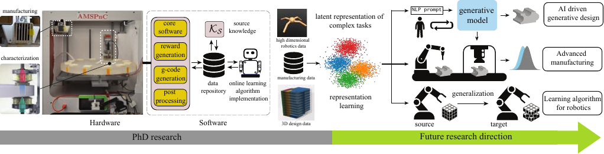